# Final Results and Project Report

## Checking efficiency by measuring the time for train and test

Efficiency of the Logistic Regression model

```r
tic("Total_glm")
tic("glm_train")
glm_model <- glm(Either_Or_Both ~.,newDF_train, family = "binomial")
toc()
```

```
## glm_train: 0.62 sec elapsed
```

```r
tic("glm_test")
predict_glm_model <-predict(glm_model, newDF_test, type = "response")
toc()
```

```
## glm_test: 0 sec elapsed
```

```r
toc()
```

```
## Total_glm: 0.62 sec elapsed
```

# Recomputing Decision Tree model using the new dependent variables

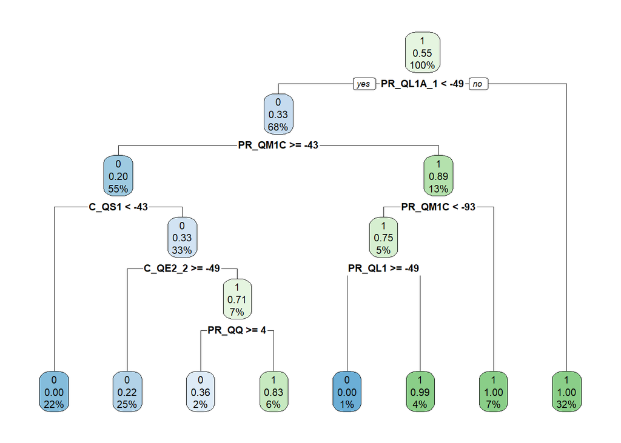

```r
fit2 <- rpart(Either_Or_Both~., data = newDF_train, method = 'class')
rpart.plot(fit2, extra = "auto")
```

```r
predict_class_model <-predict(fit2, newDF_test, type = 'class')

table_class <- table(Actual_=newDF_test$Either_Or_Both, Predicted_=predict_class_model)

table_class
```

```
##        Predicted_
## Actual_    0    1
##       0 2982   64
##       1  439 3238
```

Confusion Matrix and Statistics

```r
confusionMatrix(table_class)
```

```
## Confusion Matrix and Statistics
##
##        Predicted_
## Actual_    0    1
##       0 2982   64
##       1  439 3238
##
##                Accuracy : 0.9252
##                  95% CI : (0.9186, 0.9314)
##     No Information Rate : 0.5089
##     P-Value [Acc > NIR] : < 2.2e-16
##
##                   Kappa : 0.8506
##
##  Mcnemar's Test P-Value : < 2.2e-16
##
##             Sensitivity : 0.8717
##             Specificity : 0.9806
##          Pos Pred Value : 0.9790
##          Neg Pred Value : 0.8806
##              Prevalence : 0.5089
##          Detection Rate : 0.4436
##    Detection Prevalence : 0.4531
##       Balanced Accuracy : 0.9261
##
##        'Positive' Class : 0
##
```

## Checking efficiency by measuring the time for train and test

Efficiency of the Decision Tree model

```r
tic("Total_dTree")
tic("dTree_train")
fit2 <- rpart(Either_Or_Both~., data = newDF_train, method = 'class')
toc()
```

```
## dTree_train: 0.48 sec elapsed
```

```r
tic("dTree_test")
predict_class_model <-predict(fit2, newDF_test, type = 'class')
toc()
```

```
## dTree_test: 0 sec elapsed
```

```r
toc()
```

```
## Total_dTree: 0.48 sec elapsed
```

## Now let us attempt to generate the decision tree using Random Forest method.

First we install and load the pachage needed.

```r
#install.packages("randomForest")

library(randomForest)
```

Now we fit the model and review it.

### Note that all attempts to generate a Classification type model failed, displaying “Error: Cannot allocate vector of size 5.4Gb”, before terminating the process. The below code only generates a Regression model. consequently, we will not be exploring this further.

```r
# This is the correct code to use for Classification but gives an error

#fit_RF <- randomForest(Either_Or_Both~., data = newDF_train, importance = TRUE, proximity = TRUE)


fit_RF <- randomForest(Either_Or_Both~., data = newDF_train)
print(fit_RF)
```

```
##
## Call:
##  randomForest(formula = Either_Or_Both ~ ., data = newDF_train)
##                Type of random forest: regression
##                      Number of trees: 500
## No. of variables tried at each split: 6
##
##           Mean of squared residuals: 0.0471217
##                     % Var explained: 80.99
```

# Using k-Nearest Neighbors (KNN) Algorithm

If the data is not normalized it will lead to a biased outcome. To normalize, we first create a Normalization function.

```r
normalize <- function(x) {
return ((x - min(x)) / (max(x) - min(x))) }
```

Then we normalize the data, but not before removing the dependent variable from the dataset.

```r
newDF.n <- newDF

newDF.norm <- as.data.frame(lapply(newDF.n[,1:18], normalize))

newDF.norm <- cbind(newDF.n$Either_Or_Both, newDF.norm)

head(newDF.norm)
```

```
##   newDF.n$Either_Or_Both    PR_QL1 C_QE2_2 C_QRB1_1 C_QRB1_2 C_QS2_3    C_QRB2
## 1                      1 0.9528302       0        0        0       0 0.0000000
## 2                      1 0.9622642       1        1        0       0 0.9805825
## 3                      1 0.9905660       0        0        0       0 0.0000000
## 4                      1 0.9528302       1        1        1       0 0.9708738
## 5                      1 0.9528302       1        1        1       0 0.9805825
## 6                      1 0.9528302       1        0        0       0 0.0000000
##      C_QS1     C_QS3 C_QRB1_3 C_QS2_1   PR_AGE1 PR_QL1A_1 PR_QL1A_2 PR_QL1A_3
## 1 1.000000 0.0000000        0       0 0.9523810      0.99         1      0.99
## 2 0.990099 0.9805825        0       0 0.9619048      0.00         0      0.00
## 3 1.000000 0.0000000        0       0 0.9523810      0.00         0      0.00
## 4 0.990099 0.9805825        0       1 0.9619048      0.99         1      0.99
## 5 1.000000 0.0000000        0       0 0.9619048      0.99         1      0.99
## 6 1.000000 0.0000000        0       0 0.9619048      0.99         1      0.99
##   PR_QL1A_4   PR_QM1C PR_QO1_C_COMBINE        PR_QQ
## 1      0.99 0.9900990                1 1.099892e-05
## 2      0.00 0.1089109                1 1.009901e-04
## 3      0.00 1.0000000                1 1.009901e-04
## 4      0.99 1.0000000                1 1.009901e-04
## 5      0.99 0.9900990                1 1.019900e-04
## 6      0.99 0.1089109                1 1.019900e-04
```

After normalizing, we split the data set into training and testing data set.

```r
set.seed(545)
index <- sample(1:nrow(newDF.norm), 0.8 * nrow(newDF.norm))
DF.norm_train <- newDF.norm[index,]
DF.norm_test <- newDF.norm[-index,]


head(DF.norm_train)
```

```
##       newDF.n$Either_Or_Both    PR_QL1 C_QE2_2 C_QRB1_1 C_QRB1_2 C_QS2_3
## 28973                      0 0.9433962       0        0        0       0
## 30419                      0 1.0000000       0        0        0       0
## 11719                      1 0.9528302       0        0        0       0
## 28910                      0 0.9622642       0        0        0       0
## 16323                      1 0.9528302       1        1        1       0
## 32447                      0 0.9716981       0        0        0       0
##          C_QRB2    C_QS1     C_QS3 C_QRB1_3 C_QS2_1   PR_AGE1 PR_QL1A_1
## 28973 0.0000000 0.000000 0.0000000        0       0 0.9619048      0.00
## 30419 0.0000000 0.000000 0.0000000        0       0 0.9809524      0.00
## 11719 0.0000000 0.990099 1.0000000        0       0 0.9523810      0.99
## 28910 0.0000000 0.000000 0.0000000        0       0 0.9619048      0.00
## 16323 0.9708738 0.990099 0.9708738        0       1 0.9714286      0.99
## 32447 0.0000000 0.000000 0.0000000        0       0 0.9809524      0.00
##       PR_QL1A_2 PR_QL1A_3 PR_QL1A_4   PR_QM1C PR_QO1_C_COMBINE        PR_QQ
## 28973      0.00      0.00      0.00 1.0000000                1 0.0000999902
## 30419      0.00      0.00      0.00 1.0000000                1 0.0001029899
## 11719      1.00      0.99      0.99 0.1089109                1 0.0001029899
## 28910      0.00      0.00      0.00 1.0000000                1 0.0001029899
## 16323      0.99      0.99      1.00 1.0000000                1 0.0001019900
## 32447      0.00      0.00      0.00 1.0000000                1 0.0001019900
```

We now create the train and test labels for comparing results by extracting the dependent variable, Either_Or_Both, from the new dataframe.

```r
DF.n_train_labels <- DF.norm_train[,1]
DF.n_test_labels <- DF.norm_test[,1]
```

Calculate the square root of the number of observations in the training data set to use in determining the optimal value of ‘K’ in the KNN model.

```r
round(sqrt(NROW(DF.n_train_labels)))
```

```
## [1] 164
```

Creating the KNN algorithm model and using the model to make a prediction.

```r
DF.n_test_pred <- knn(train = DF.norm_train[,2:19],
test = DF.norm_test[,2:19],
cl = DF.norm_train[,1], k=164)

head(DF.n_test_pred)
```

```
## [1] 1 1 1 1 1 1
## Levels: 0 1
```

Evaluating the model

```r
table_KNN <- table(Actual=DF.n_test_labels, Predicted=DF.n_test_pred)

table_KNN
```

```
##       Predicted
## Actual    0    1
##      0 2927  118
##      1  468 3210
```

Confusion Matrix and Statistics

```r
confusionMatrix(table_KNN)
```

```
## Confusion Matrix and Statistics
##
##       Predicted
## Actual    0    1
##      0 2927  118
##      1  468 3210
##
##                Accuracy : 0.9128
##                  95% CI : (0.9058, 0.9195)
##     No Information Rate : 0.505
##     P-Value [Acc > NIR] : < 2.2e-16
##
##                   Kappa : 0.8258
##
##  Mcnemar's Test P-Value : < 2.2e-16
##
##             Sensitivity : 0.8622
##             Specificity : 0.9645
##          Pos Pred Value : 0.9612
##          Neg Pred Value : 0.8728
##              Prevalence : 0.5050
##          Detection Rate : 0.4354
##    Detection Prevalence : 0.4529
##       Balanced Accuracy : 0.9133
##
##        'Positive' Class : 0
##
```

## Checking efficiency by measuring the time for train and test

Efficiecy of the k-Nearest Neighbors model

```r
tic("Total_KNN")
tic("KNN_train")
DF.n_test_pred <- knn(train = DF.norm_train[,2:19], test = DF.norm_test[,2:19], cl = DF.norm_train[,1], k=164)
toc()
```

```
## KNN_train: 3.89 sec elapsed
```

```r
tic("KNN_test")
table_KNN <- table(Actual=DF.n_test_labels, Predicted=DF.n_test_pred)
toc()
```

```
## KNN_test: 0.01 sec elapsed
```

```r
toc()
```

```
## Total_KNN: 3.9 sec elapsed
```

# Performing Cross-Validation on the Three Procedures

Let’s define a train control model with K = 10 with 5 repeats

```r
# defining training control as repeated cross-validation and value of K is 10 and repetition is 5 times

set.seed(120)

train_control <- trainControl(method = "repeatedcv",
                            number = 10, repeats = 5)
```

## Repeated K-fold cross-validation - Decision Tree Model

```r
DT_model <- train(Either_Or_Both~., data = newDF_train,
               trControl = train_control,
               method = "rpart")
print(DT_model)
```

```
## CART
##
## 26892 samples
##    18 predictor
##
## No pre-processing
## Resampling: Cross-Validated (10 fold, repeated 5 times)
## Summary of sample sizes: 24203, 24202, 24203, 24203, 24203, 24203, ...
## Resampling results across tuning parameters:
##
##   cp          RMSE       Rsquared   MAE
##   0.05881095  0.3045250  0.6248430  0.1854077
##   0.19959693  0.3534965  0.4913519  0.2505833
##   0.39819685  0.4502927  0.3871880  0.4105938
##
## RMSE was used to select the optimal model using the smallest value.
## The final value used for the model was cp = 0.05881095.
```

## Repeated K-fold cross-validation - Linear Regression Model

```r
LM_model <- train(Either_Or_Both~., data = newDF_train,
               trControl = train_control,
               method = "lm")
print(LM_model)
```

```
## Linear Regression
##
## 26892 samples
##    18 predictor
##
## No pre-processing
## Resampling: Cross-Validated (10 fold, repeated 5 times)
## Summary of sample sizes: 24202, 24203, 24202, 24203, 24203, 24203, ...
## Resampling results:
##
##   RMSE       Rsquared   MAE
##   0.2872896  0.6669755  0.2094923
##
## Tuning parameter 'intercept' was held constant at a value of TRUE
```

```r
train = DF.norm_train[,2:19]
cl = DF.norm_train[,1]

KNN_model = train(x = train,
                y = cl,
                method = "knn")
                trControl = train_control

print(KNN_model)
```

```
## k-Nearest Neighbors
##
## 26892 samples
##    18 predictor
##
## No pre-processing
## Resampling: Bootstrapped (25 reps)
## Summary of sample sizes: 26892, 26892, 26892, 26892, 26892, 26892, ...
## Resampling results across tuning parameters:
##
##   k  RMSE       Rsquared   MAE
##   5  0.2494504  0.7524600  0.09755850
##   7  0.2450836  0.7599921  0.09855168
##   9  0.2428542  0.7637671  0.09968792
##
## RMSE was used to select the optimal model using the smallest value.
## The final value used for the model was k = 9.
```

# Comparing Accuracy, Sensitivity, Specificity, Rsquared, Mean Absolute Error (MAE), and Root Mean Square Error (RMSE)

DTree - Accuracy : 0.9252  
Sensitivity : 0.8717 Specificity : 0.9806 RMSE : 0.3045250  
Rsquared : 0.6248430  
MAE : 0.1854077

KNN - Accuracy : 0.9128  
Sensitivity : 0.8622 Specificity : 0.9645 RMSE : 0.2428542  
Rsquared : 0.7637671  
MAE : 0.09968792